# Assignment 6

Dustin Poon

2023-03-27

```r
data <- read_csv("original_elections_335.csv",show_col_types = FALSE) #,skip_empty_rows =T, na= c("","NA", "NaN")
```

```r
filterData <- data %>%
    filter(CombinedParty == "Liberal"| CombinedParty == "Conservative Party of Canada") %>% filter(RepeatParty == 1)
filterData <- filterData %>%
    mutate(Mvprev = as.numeric(Mvprev)*100)
```

```r
meanMvprev <- mean(filterData$Mvprev, na.rm = T) # average margin of victory in the previous election
meanMvprev
```

```
## [1] -0.562068
```

```r
meanCurr <- mean(filterData$Mvprev[filterData$DeclaredWinner == 1],na.rm = T) #mean probability of winning the current election, after making these changes.
meanCurr
```

```
## [1] 15.95683
```

# Question 2

```r
filterData <- filterData%>%
  drop_na(Mvprev)%>%
  mutate(roundedMvprev = round(Mvprev))

groupedData <- filterData%>%
  group_by(roundedMvprev)%>%
  summarize(probWin = mean(DeclaredWinner, na.rm = T))%>%
  mutate(incumbent = roundedMvprev >= 0)
```

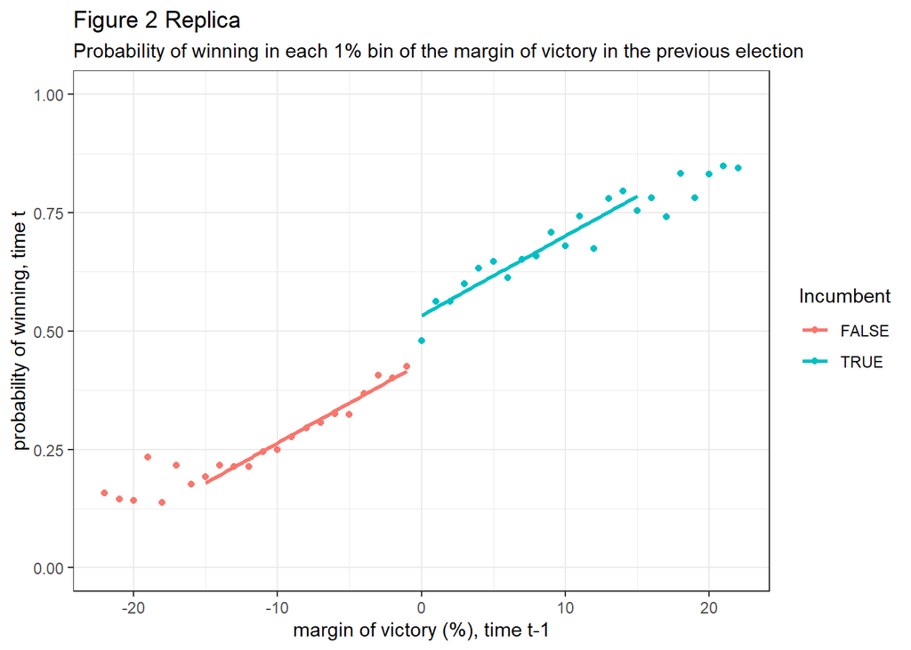

```r
df_sub <- groupedData[groupedData$roundedMvprev >= -15 & groupedData$roundedMvprev <= 15,]


p <-  ggplot(data = groupedData, mapping = aes(x=roundedMvprev, y = probWin, color= incumbent))

p <- p + geom_smooth(data = df_sub, method = "lm", se = FALSE)

p + geom_point() + xlim(-22, 22) +
  labs(x= "margin of victory (%), time t-1",
        y= "probability of winning, time t",
       colour = "Incumbent",
       title = "Figure 2 Replica",
       subtitle = "Probability of winning in each 1% bin of the margin of victory in the previous election") + theme_bw()
```

What does this Figure indicate about the causal effect of incumbency (if any) on the probability of winning? Explain

Ans: Suggests that incumbency has a significant positive effect on the probability of winning the election. There is evidence of discontinuity at c based on the incumbent status.

# Question 3

```r
filterData <- filterData %>%
  mutate(incumbent = (Mvprev >= 0),
         mv2 = Mvprev^2,
         mv3 = Mvprev^3,
         mv4 = Mvprev^4,
         mvIn = Mvprev*incumbent,
         mv2In = Mvprev^2*incumbent,
         mv3In = Mvprev^3*incumbent,
         mv4In = Mvprev^4*incumbent
         )
# FParliament <- factor(filterData$Parliament)
# FProvince <- factor(filterData$Province)
```

```r
df_15 <- filterData[filterData$Mvprev >= -15 & filterData$Mvprev <= 15,]

# Estimate linear regression model
model15 <- lm(data= df_15, DeclaredWinner ~  incumbent + Mvprev+ mvIn+ factor(Parliament) + factor(Province) , na.action = na.exclude)

# Print summary of model results
out15 <- summary(model15)
out15
```

```
##
## Call:
## lm(formula = DeclaredWinner ~ incumbent + Mvprev + mvIn + factor(Parliament) +
##     factor(Province), data = df_15, na.action = na.exclude)
##
## Residuals:
##     Min      1Q  Median      3Q     Max
## -0.9768 -0.3816 -0.1412  0.3930  0.9368
##
## Coefficients:
##                                             Estimate Std. Error t value
## (Intercept)                                0.3699505  0.0700839   5.279
## incumbentTRUE                              0.1117658  0.0215533   5.186
## Mvprev                                     0.0155895  0.0019238   8.103
## mvIn                                       0.0012307  0.0027645   0.445
## factor(Parliament)3                        0.1452330  0.0773428   1.878
## factor(Parliament)4                        0.0808001  0.0860463   0.939
## factor(Parliament)5                        0.1168109  0.0713437   1.637
## factor(Parliament)6                        0.0210610  0.0696628   0.302
## factor(Parliament)7                       -0.0110618  0.0660376  -0.168
## factor(Parliament)8                       -0.0019399  0.0704295  -0.028
## factor(Parliament)9                       -0.0008129  0.0647400  -0.013
## factor(Parliament)10                       0.0053400  0.0665024   0.080
## factor(Parliament)11                      -0.0036346  0.0648848  -0.056
## factor(Parliament)12                       0.0053819  0.0637144   0.084
## factor(Parliament)14                      -0.2383630  0.4662205  -0.511
## factor(Parliament)15                       0.1327277  0.0731096   1.815
## factor(Parliament)16                      -0.0429437  0.0658249  -0.652
## factor(Parliament)17                       0.0277257  0.0666811   0.416
## factor(Parliament)18                      -0.0437586  0.0664699  -0.658
## factor(Parliament)19                       0.1158168  0.0720337   1.608
## factor(Parliament)20                      -0.2269343  0.0708828  -3.202
## factor(Parliament)21                       0.0548837  0.0673138   0.815
## factor(Parliament)22                      -0.0534460  0.0678269  -0.788
## factor(Parliament)23                      -0.0665222  0.0659836  -1.008
## factor(Parliament)24                      -0.0125724  0.0655640  -0.192
## factor(Parliament)25                      -0.1391499  0.0664569  -2.094
## factor(Parliament)26                      -0.0210078  0.0638387  -0.329
## factor(Parliament)27                      -0.0010180  0.0654453  -0.016
## factor(Parliament)28                       0.0196731  0.0744291   0.264
```

[output cut: 69 more lines]

```
## factor(Province)Newfoundland and Labrador  0.13091
## factor(Province)Northwest Territories      0.74436
## factor(Province)Nova Scotia                0.01727 *
## factor(Province)Nunavut                    0.72482
## factor(Province)Ontario                    0.02612 *
## factor(Province)Prince Edward Island       0.02582 *
## factor(Province)Quebec                     0.03128 *
## factor(Province)Saskatchewan               0.33883
## factor(Province)Yukon                      0.52216
## ---
## Signif. codes:  0 '***' 0.001 '**' 0.01 '*' 0.05 '.' 0.1 ' ' 1
##
## Residual standard error: 0.4623 on 6412 degrees of freedom
## Multiple R-squared:  0.1513, Adjusted R-squared:  0.1444
## F-statistic: 21.98 on 52 and 6412 DF,  p-value: < 2.2e-16
```

```r
value15 <- out15$coefficients[2]
```

```r
df_10 <- filterData[filterData$Mvprev >= -10 & filterData$Mvprev <= 10,]

# Estimate linear regression model
model10 <- lm(data= df_10, DeclaredWinner ~  incumbent + Mvprev+ mvIn+ factor(Parliament) + factor(Province) , na.action = na.exclude)

# Print summary of model results
out10 <- summary(model10)
out10
```

```
##
## Call:
## lm(formula = DeclaredWinner ~ incumbent + Mvprev + mvIn + factor(Parliament) +
##     factor(Province), data = df_10, na.action = na.exclude)
##
## Residuals:
##     Min      1Q  Median      3Q     Max
## -0.8969 -0.4116 -0.1751  0.4226  0.8773
##
## Coefficients:
##                                             Estimate Std. Error t value
## (Intercept)                                3.895e-01  8.383e-02   4.646
## incumbentTRUE                              9.411e-02  2.659e-02   3.539
## Mvprev                                     1.866e-02  3.476e-03   5.367
## mvIn                                      -6.367e-06  4.938e-03  -0.001
## factor(Parliament)3                        1.615e-01  8.958e-02   1.803
## factor(Parliament)4                        6.758e-02  9.945e-02   0.680
## factor(Parliament)5                        1.071e-01  8.337e-02   1.285
## factor(Parliament)6                       -2.722e-02  8.082e-02  -0.337
## factor(Parliament)7                       -4.282e-02  7.673e-02  -0.558
## factor(Parliament)8                       -2.147e-02  8.191e-02  -0.262
## factor(Parliament)9                       -2.906e-02  7.561e-02  -0.384
## factor(Parliament)10                      -1.073e-02  7.777e-02  -0.138
## factor(Parliament)11                      -2.833e-02  7.577e-02  -0.374
## factor(Parliament)12                      -1.515e-02  7.456e-02  -0.203
## factor(Parliament)15                       1.199e-01  8.518e-02   1.407
## factor(Parliament)16                      -9.439e-02  7.950e-02  -1.187
## factor(Parliament)17                      -1.473e-03  7.860e-02  -0.019
## factor(Parliament)18                      -6.885e-02  7.944e-02  -0.867
## factor(Parliament)19                       1.092e-01  8.502e-02   1.284
## factor(Parliament)20                      -2.095e-01  8.421e-02  -2.488
## factor(Parliament)21                       3.347e-02  7.900e-02   0.424
## factor(Parliament)22                      -8.062e-02  7.950e-02  -1.014
## factor(Parliament)23                      -9.717e-02  7.828e-02  -1.241
## factor(Parliament)24                      -5.131e-02  7.734e-02  -0.663
## factor(Parliament)25                      -1.868e-01  7.892e-02  -2.366
## factor(Parliament)26                      -4.561e-02  7.581e-02  -0.602
## factor(Parliament)27                      -1.989e-02  7.660e-02  -0.260
## factor(Parliament)28                      -1.993e-02  8.898e-02  -0.224
## factor(Parliament)29                      -8.671e-02  7.759e-02  -1.118
```

[output cut: 65 more lines]

```
## factor(Province)New Brunswick             0.023633 *
## factor(Province)Newfoundland and Labrador 0.189215
## factor(Province)Northwest Territories     0.926257
## factor(Province)Nova Scotia               0.026878 *
## factor(Province)Ontario                   0.037904 *
## factor(Province)Prince Edward Island      0.044410 *
## factor(Province)Quebec                    0.025069 *
## factor(Province)Saskatchewan              0.461126
## factor(Province)Yukon                     0.249470
## ---
## Signif. codes:  0 '***' 0.001 '**' 0.01 '*' 0.05 '.' 0.1 ' ' 1
##
## Residual standard error: 0.4747 on 4691 degrees of freedom
## Multiple R-squared:  0.1076, Adjusted R-squared:  0.09809
## F-statistic: 11.31 on 50 and 4691 DF,  p-value: < 2.2e-16
```

```r
value10 <- out10$coefficients[2]
```

```r
df_70 <- filterData[filterData$Mvprev >= -70 & filterData$Mvprev <= 70,]

# Estimate linear regression model
modelCubic <- lm(data= df_70, DeclaredWinner ~  incumbent +
                   Mvprev+ mvIn +
                   mv2In+ mv2 +
                   mv3In+ mv3 + factor(Parliament) + factor(Province) , na.action = na.exclude)

# Print summary of model results
outCubic <- summary(modelCubic)
outCubic
```

```
##
## Call:
## lm(formula = DeclaredWinner ~ incumbent + Mvprev + mvIn + mv2In +
##     mv2 + mv3In + mv3 + factor(Parliament) + factor(Province),
##     data = df_70, na.action = na.exclude)
##
## Residuals:
##      Min       1Q   Median       3Q      Max
## -1.06257 -0.23958 -0.06188  0.25167  1.04132
##
## Coefficients:
##                                             Estimate Std. Error t value
## (Intercept)                                4.167e-01  4.375e-02   9.525
## incumbentTRUE                              9.421e-02  1.918e-02   4.913
## Mvprev                                     1.883e-02  2.154e-03   8.744
## mvIn                                       3.272e-03  3.193e-03   1.025
## mv2In                                     -6.912e-04  1.287e-04  -5.372
## mv2                                        3.062e-04  8.591e-05   3.564
## mv3In                                      7.066e-07  1.422e-06   0.497
## mv3                                        1.106e-06  9.361e-07   1.181
## factor(Parliament)3                        1.598e-01  5.376e-02   2.973
## factor(Parliament)4                        2.302e-02  5.767e-02   0.399
## factor(Parliament)5                        1.344e-01  5.130e-02   2.619
## factor(Parliament)6                        4.777e-02  4.949e-02   0.965
## factor(Parliament)7                        1.640e-02  4.586e-02   0.358
## factor(Parliament)8                        2.359e-02  4.952e-02   0.476
## factor(Parliament)9                        2.493e-02  4.492e-02   0.555
## factor(Parliament)10                       2.209e-02  4.613e-02   0.479
## factor(Parliament)11                       1.383e-02  4.481e-02   0.309
## factor(Parliament)12                       2.307e-02  4.379e-02   0.527
## factor(Parliament)14                      -1.486e-01  2.047e-01  -0.726
## factor(Parliament)15                       7.559e-02  4.645e-02   1.627
## factor(Parliament)16                      -1.400e-02  4.356e-02  -0.321
## factor(Parliament)17                       3.515e-02  4.407e-02   0.797
## factor(Parliament)18                      -3.978e-02  4.514e-02  -0.881
## factor(Parliament)19                       1.118e-01  4.750e-02   2.355
## factor(Parliament)20                      -1.182e-01  4.708e-02  -2.511
## factor(Parliament)21                       2.485e-02  4.432e-02   0.561
## factor(Parliament)22                      -3.090e-02  4.411e-02  -0.701
## factor(Parliament)23                      -2.699e-02  4.304e-02  -0.627
```

[output cut: 78 more lines]

```
## factor(Province)Newfoundland and Labrador 0.118027
## factor(Province)Northwest Territories     0.397740
## factor(Province)Nova Scotia               0.198674
## factor(Province)Nunavut                   0.927603
## factor(Province)Ontario                   0.087217 .
## factor(Province)Prince Edward Island      0.125754
## factor(Province)Quebec                    0.888348
## factor(Province)Saskatchewan              0.357798
## factor(Province)Yukon                     0.507011
## ---
## Signif. codes:  0 '***' 0.001 '**' 0.01 '*' 0.05 '.' 0.1 ' ' 1
##
## Residual standard error: 0.4011 on 13138 degrees of freedom
## Multiple R-squared:  0.3521, Adjusted R-squared:  0.3493
## F-statistic: 127.5 on 56 and 13138 DF,  p-value: < 2.2e-16
```

```r
valueCubic <- outCubic$coefficients[2]
```

```r
# Estimate linear regression model
modelQuartic <- lm(data= df_70, DeclaredWinner ~  incumbent +
                   Mvprev+ mvIn +
                   mv2In+ mv2 +
                   mv3In+ mv3 +
                   mv4In+ mv4 +
                     factor(Parliament) +
                     factor(Province) , na.action = na.exclude)

# Print summary of model results
outQuartic <- summary(modelQuartic)
outQuartic
```

```
##
## Call:
## lm(formula = DeclaredWinner ~ incumbent + Mvprev + mvIn + mv2In +
##     mv2 + mv3In + mv3 + mv4In + mv4 + factor(Parliament) + factor(Province),
##     data = df_70, na.action = na.exclude)
##
## Residuals:
##      Min       1Q   Median       3Q      Max
## -1.06983 -0.23855 -0.06217  0.25505  1.04011
##
## Coefficients:
##                                             Estimate Std. Error t value
## (Intercept)                                4.196e-01  4.483e-02   9.358
## incumbentTRUE                              1.019e-01  2.334e-02   4.368
## Mvprev                                     2.009e-02  4.016e-03   5.002
## mvIn                                      -2.211e-03  5.896e-03  -0.375
## mv2In                                     -4.501e-04  4.077e-04  -1.104
## mv2                                        4.024e-04  2.736e-04   1.470
## mv3In                                     -1.060e-05  1.017e-05  -1.042
## mv3                                        3.569e-06  6.721e-06   0.531
## mv4In                                      5.215e-08  8.118e-08   0.642
## mv4                                        1.976e-08  5.341e-08   0.370
## factor(Parliament)3                        1.607e-01  5.377e-02   2.989
## factor(Parliament)4                        2.318e-02  5.767e-02   0.402
## factor(Parliament)5                        1.360e-01  5.132e-02   2.649
## factor(Parliament)6                        4.877e-02  4.949e-02   0.985
## factor(Parliament)7                        1.687e-02  4.586e-02   0.368
## factor(Parliament)8                        2.477e-02  4.953e-02   0.500
## factor(Parliament)9                        2.547e-02  4.493e-02   0.567
## factor(Parliament)10                       2.297e-02  4.614e-02   0.498
## factor(Parliament)11                       1.511e-02  4.483e-02   0.337
## factor(Parliament)12                       2.395e-02  4.379e-02   0.547
## factor(Parliament)14                      -1.489e-01  2.047e-01  -0.727
## factor(Parliament)15                       7.610e-02  4.646e-02   1.638
## factor(Parliament)16                      -1.278e-02  4.357e-02  -0.293
## factor(Parliament)17                       3.628e-02  4.408e-02   0.823
## factor(Parliament)18                      -3.863e-02  4.515e-02  -0.856
## factor(Parliament)19                       1.129e-01  4.751e-02   2.376
## factor(Parliament)20                      -1.171e-01  4.709e-02  -2.487
## factor(Parliament)21                       2.560e-02  4.433e-02   0.578
```

[output cut: 82 more lines]

```
## factor(Province)Newfoundland and Labrador  0.11431
## factor(Province)Northwest Territories      0.39734
## factor(Province)Nova Scotia                0.20517
## factor(Province)Nunavut                    0.91493
## factor(Province)Ontario                    0.09103 .
## factor(Province)Prince Edward Island       0.13413
## factor(Province)Quebec                     0.89036
## factor(Province)Saskatchewan               0.36655
## factor(Province)Yukon                      0.51017
## ---
## Signif. codes:  0 '***' 0.001 '**' 0.01 '*' 0.05 '.' 0.1 ' ' 1
##
## Residual standard error: 0.4011 on 13136 degrees of freedom
## Multiple R-squared:  0.3521, Adjusted R-squared:  0.3493
## F-statistic: 123.1 on 58 and 13136 DF,  p-value: < 2.2e-16
```

```r
valueQuartic <- outQuartic$coefficients[2]
```

```r
type <- c("Linear (+/-15%)", "Linear (+/-10%)", "Cubic", "Quartic")
value <- c(value15 ,value10,valueCubic,valueQuartic)
dfQ3 <- data.frame(`Overall incumbency` = type , Estimates = round(value, 4))
dfQ3
```

```
##   Overall.incumbency Estimates
## 1    Linear (+/-15%)    0.1118
## 2    Linear (+/-10%)    0.0941
## 3              Cubic    0.0942
## 4            Quartic    0.1019
```

What do the regression estimates indicate about the causal effect of incumbency (if any) on the probability of winning? Explain.

- It means that, on average, incumbent parties, whether running an incumbent candidate or not, are more likely to win an election than non-incumbent parties.
- There is a 9.4% to 11.2% increase in probability of winning on average for overall incumbency effect. On average, incumbency increase probability of winning by about 10%.

# Question 4

According to “Treatment at the discontinuity assumptions”. We need local randomization and continuity.

It is suggested by McCrary that we can test local randomization by looking at the distribution of X near c, which is given by looking at the historgram.

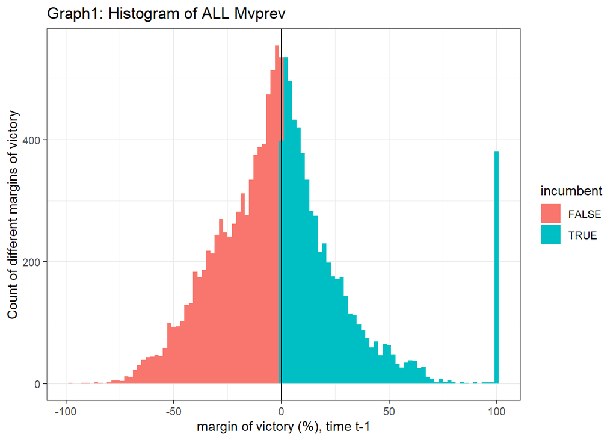

```r
p <-  ggplot(data = filterData, mapping = aes(x=roundedMvprev, fill= incumbent))

p + geom_histogram(bins = 100)+ geom_vline(xintercept = 0)+
  labs(x= "margin of victory (%), time t-1",
        y= "Count of different margins of victory",
       colour = "Incumbent",
       title = "Graph1: Histogram of ALL Mvprev") + theme_bw()
```

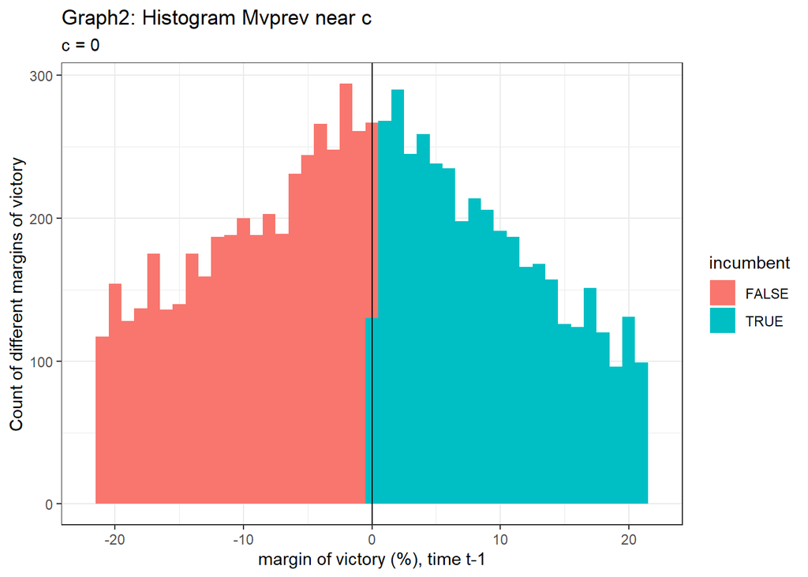

```r
p + geom_histogram(binwidth = 1) + xlim(-22, 22) + geom_vline(xintercept = 0)+
  labs(x= "margin of victory (%), time t-1",
        y= "Count of different margins of victory",
       colour = "Incumbent",
       title = "Graph2: Histogram Mvprev near c",
       subtitle = "c = 0") + theme_bw()
```

- I would suggest that the both sides looks pretty symmetric. No sudden increase of either side (incumbent = TRUE in this case). In other words there are no systematic bunching. However, there is a high count of outlines at the 100% margin of victory. So, people cannot manipulate margin of victory (x) near c, and it makes sense, to become the incumbent or not is determine by the citizen’s vote and not for the candidate to decide themselves.
- I am not sure about testing the continuity assumption. It is suggested in the lecture notes that, under local randomization, the distribution of X should be continuous near c. I don’t think we can test continuity but rather we can observe the continuity.
- “Smoothness” is mentioned in the lecture notes towards continuity assumption. Maybe, we can observe the smoothness of the continuity assumption by plotting using a line graph. According to the line graph below we can see that neither lines are super smooth. So, continuity assumption might not be valid.

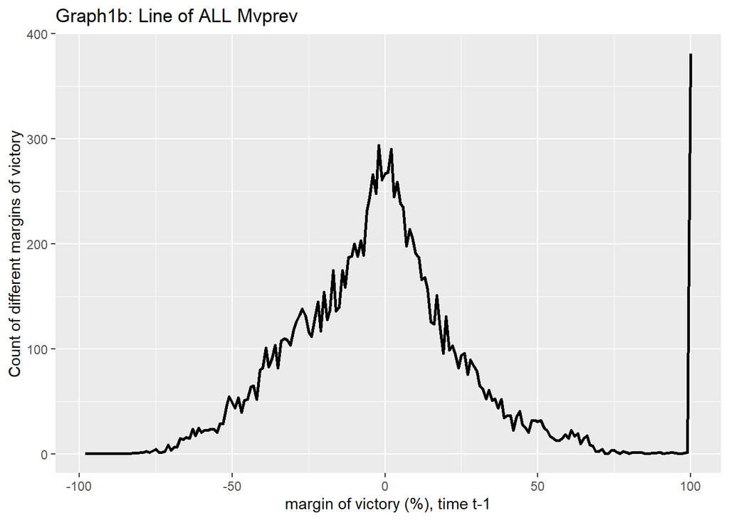

```r
sumData <- filterData %>%
  group_by(roundedMvprev)%>%
  summarise(count =n())

p2 <- ggplot(data=sumData, aes(x =roundedMvprev, y=count))
p2 + geom_line(linewidth= 1)+
  labs(x= "margin of victory (%), time t-1",
        y= "Count of different margins of victory",
       colour = "Incumbent",
       title = "Graph1b: Line of ALL Mvprev")
```

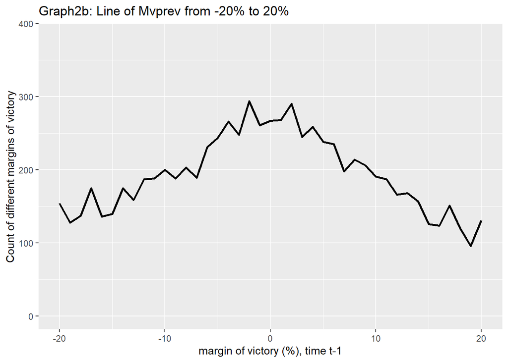

```r
p2 + geom_line(linewidth= 1) +xlim(-20,20)+
  labs(x= "margin of victory (%), time t-1",
        y= "Count of different margins of victory",
       colour = "Incumbent",
       title = "Graph2b: Line of Mvprev from -20% to 20%")
```

# Question 5

Table 1 don’t include many observable control variables because we are looking for the difference in effect between the two groups. Since the discontinuity assumptions is valid, we can assume that the people close to c is random and is the same. It would affect the interpretation in question 3 if the “observable control variables” are related to the probability of winning (Y) then the estimate and the se will be different.